# Caso estudio: Vivenda A&C

Alvaro Pérez Niño

Octubre de 2023

## Problemática

Con base en los datos de ofertas de vivienda descargadas del portal Fincaraiz para apartamento de estrato 4 con área construida menor a 200 m2 (vivienda4.RDS) la inmobiliaria A&C requiere el apoyo de un cientifico de datos en la construcción de un modelo que lo oriente sobre los precios de inmuebles.

Con este propósito el equipo de asesores a diseñado los siguientes pasos para obtener un modelo y así poder a futuro determinar los precios de los inmuebles a negociar:

### Gestión de librerías

```r
library(gdata)
library(dplyr)
library(ggplot2)
library(GGally)
library(e1071)
library(psych)
library(lmtest)
library(ggfortify)
library(sandwich)
library(MASS)
library(kableExtra)
```

### Lectura del Dataset

```r
# Lectura del dataset
Datos <- read.csv(file = file.choose(), header = TRUE, sep = ",")
```

### Filtro del Dataset conforme a las indicaciones del caso estudio

```r
# Filtro del dataset por Apartamento
tipo_vivienda <- "Apartamento"
DatosFiltrado <- subset(Datos, tipo == tipo_vivienda)
```

### Información general del Dataset

```r
# Información de las variables
str(DatosFiltrado)
```

```
## 'data.frame':    1363 obs. of  5 variables:
##  $ zona     : chr  "Zona Norte" "Zona Norte" "Zona Sur" "Zona Norte" ...
##  $ estrato  : int  4 4 4 4 4 4 4 4 4 4 ...
##  $ preciom  : int  220 320 290 220 220 162 225 370 155 240 ...
##  $ areaconst: int  52 108 96 82 75 60 84 117 60 75 ...
##  $ tipo     : chr  "Apartamento" "Apartamento" "Apartamento" "Apartamento" ...
```

### Descripción estadística inicial del Dataset

```r
# Descripción de estadistica Inicial
summary(DatosFiltrado)
```

```
##      zona              estrato     preciom        areaconst
##  Length:1363        Min.   :4   Min.   : 78.0   Min.   : 40.00
##  Class :character   1st Qu.:4   1st Qu.:153.5   1st Qu.: 60.00
##  Mode  :character   Median :4   Median :185.0   Median : 70.00
##                     Mean   :4   Mean   :202.4   Mean   : 75.48
##                     3rd Qu.:4   3rd Qu.:240.0   3rd Qu.: 84.00
##                     Max.   :4   Max.   :645.0   Max.   :200.00
##      tipo
##  Length:1363
##  Class :character
##  Mode  :character
##
##
##
```

### Verificación de valores nulos y vacíos

```r
# Verificar valores nulos
valores_nulos <- colSums(is.na(DatosFiltrado))

# Verificar valores vacíos
valores_vacios <- colSums(sapply(DatosFiltrado, function(x) x == ""))

# Crear un dataframe que muestra los valores Nulos y Vacios
resultado <- data.frame(
  Columna = colnames(DatosFiltrado),
  ValoresNulos = valores_nulos,
  ValoresVacios = valores_vacios
)

# Mostrar el resultado
print(resultado)
```

```
##             Columna ValoresNulos ValoresVacios
## zona           zona            0             0
## estrato     estrato            0             0
## preciom     preciom            0             0
## areaconst areaconst            0             0
## tipo           tipo            0             0
```

### Representación gráfica de las variables del Dataset

#### Gráfico de barras para la columna “zona”

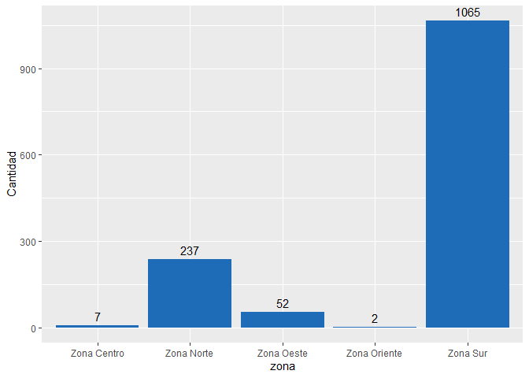

#### Gráfico de barras para la columna “estrato”

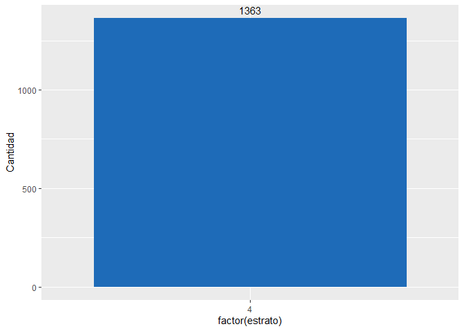

#### Gráfico de cajas (boxplot) para la columna “preciom”

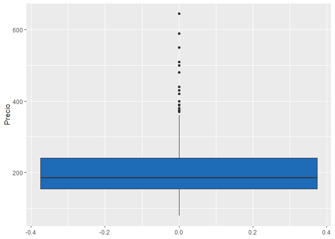

#### Gráfico de cajas (boxplot) para la columna “areaconst”

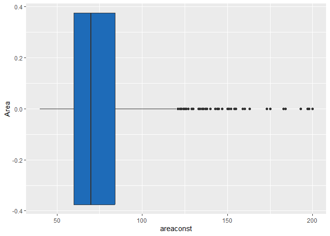

#### Matriz de gráficos de las variables del Dataset

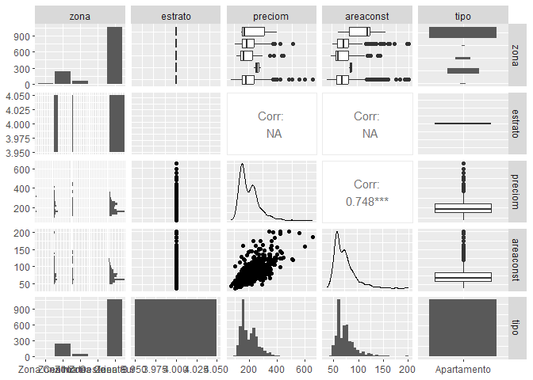

## Punto No.01:

Realice un análisis exploratorio de las variables precio de vivienda (millones de pesos COP) y área de la vivienda (metros cuadrados):

### 1.1 Indicadores estadísticos de la variable precio de vivienda (millones de pesos COP):

```r
# Cálculo de indicadores estadísticos
media <- mean(DatosFiltrado$preciom)
mediana <- median(DatosFiltrado$preciom)
moda <- DatosFiltrado %>% count(preciom) %>% filter(n == max(n)) %>% pull(preciom)
maximo <- max(DatosFiltrado$preciom)
minimo <- min(DatosFiltrado$preciom)
desviacion_estandar <- sd(DatosFiltrado$preciom)
varianza <- var(DatosFiltrado$preciom)
sesgo <- skewness(DatosFiltrado$preciom)
curtosis <- kurtosis(DatosFiltrado$preciom)
se <- sd(DatosFiltrado$preciom) / sqrt(length(DatosFiltrado$preciom))

# Crear la tabla de indicadores
tabla_markdown <- data.frame(
  "Estadística" = c("Media", "Mediana", "Moda", "Máximo", "Mínimo", "Desviación Estándar", "Varianza", "Sesgo", "Curtosis", "Error Estándar"),
  "Valor" = c(media, mediana, moda, maximo, minimo, desviacion_estandar, varianza, sesgo, curtosis, se)
)

# Imprimir la tabla de indicadores
knitr::kable(tabla_markdown, format = "markdown")
```

| Estadística | Valor |
| --- | --- |
| Media | 202.437271 |
| Mediana | 185.000000 |
| Moda | 150.000000 |
| Máximo | 645.000000 |
| Mínimo | 78.000000 |
| Desviación Estándar | 65.290492 |
| Varianza | 4262.848302 |
| Sesgo | 1.442664 |
| Curtosis | 3.833419 |
| Error Estándar | 1.768488 |

### 1.2 Gráfico estadístico de la variable precio de vivienda (millones de pesos COP):

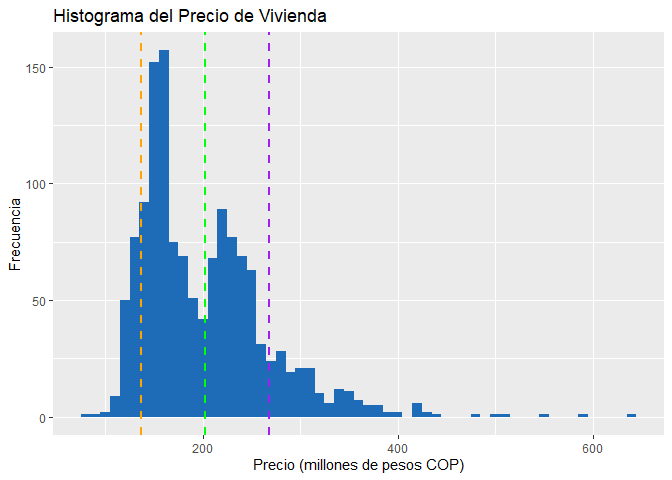

```r
# Crear el histograma
ggplot(DatosFiltrado, aes(x = preciom)) +
  geom_histogram(binwidth = 10, fill = "#1E6BB8",) +
  labs(title = "Histograma del Precio de Vivienda",
       x = "Precio (millones de pesos COP)",
       y = "Frecuencia") +
  geom_vline(xintercept = media, color = "green", linetype = "dashed", size = 1) +
  geom_vline(xintercept = media + desviacion_estandar, color = "purple", linetype = "dashed", size = 1) +
  geom_vline(xintercept = media - desviacion_estandar, color = "orange", linetype = "dashed", size = 1)
```

### 1.3 Interpretación de resultados de la variable precio de vivienda (millones de pesos COP):

La variable precio de vivienda (expresada en millones de pesos colombianos, COP) presenta una distribución con varios indicadores estadísticos clave que nos ayudan a comprender su comportamiento. La media del precio de vivienda es de 202.437 millones de COP, lo que sugiere que, en promedio, las viviendas tienen un precio cercano a esta cifra. La mediana, que es de 185 millones de COP, es un indicador que señala que el valor medio se encuentra en un punto intermedio de la distribución, lo que puede sugerir que hay cierta asimetría en la distribución. La moda, que es de 150 millones de COP, indica que este valor es el que más frecuentemente se repite en los datos, lo que puede ser útil para identificar los precios más comunes en el mercado de viviendas. El precio máximo registrado es de 645 millones de COP, mientras que el mínimo es de 78 millones de COP, lo que muestra la amplia gama de precios en el mercado.

### 1.4 Indicadores estadísticos de la variable área de la vivienda (metros cuadrados):

```r
# Cálculo de indicadores estadísticos
media1 <- mean(DatosFiltrado$areaconst)
mediana1 <- median(DatosFiltrado$areaconst)
moda1 <- DatosFiltrado %>% count(areaconst) %>% filter(n == max(n)) %>% pull(areaconst)
maximo1 <- max(DatosFiltrado$areaconst)
minimo1 <- min(DatosFiltrado$areaconst)
desviacion_estandar1 <- sd(DatosFiltrado$areaconst)
varianza1 <- var(DatosFiltrado$areaconst)
sesgo1 <- skewness(DatosFiltrado$areaconst)
curtosis1 <- kurtosis(DatosFiltrado$areaconst)
se1 <- sd(DatosFiltrado$areaconst) / sqrt(length(DatosFiltrado$areaconst))

# Crear la tabla de indicadores
tabla_markdown <- data.frame(
  "Estadística" = c("Media", "Mediana", "Moda", "Máximo", "Mínimo", "Desviación Estándar", "Varianza", "Sesgo", "Curtosis", "Error Estándar"),
  "Valor" = c(media1, mediana1, moda1, maximo1, minimo1, desviacion_estandar1, varianza1, sesgo1, curtosis1, se1)
)

# Imprimir la tabla de indicadores
knitr::kable(tabla_markdown, format = "markdown")
```

| Estadística | Valor |
| --- | --- |
| Media | 75.4783566 |
| Mediana | 70.0000000 |
| Moda | 60.0000000 |
| Máximo | 200.0000000 |
| Mínimo | 40.0000000 |
| Desviación Estándar | 22.5646097 |
| Varianza | 509.1616090 |
| Sesgo | 2.0821956 |
| Curtosis | 6.3235763 |
| Error Estándar | 0.6111951 |

### 1.5 Gráfico estadístico de la variable área de la vivienda (metros cuadrados):

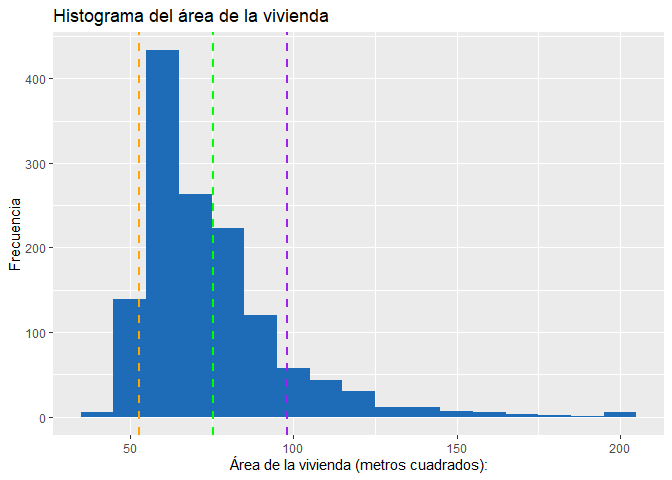

```r
# Crear el histograma
ggplot(DatosFiltrado, aes(x = areaconst)) +
  geom_histogram(binwidth = 10, fill = "#1E6BB8",) +
  labs(title = "Histograma del área de la vivienda",
       x = "Área de la vivienda (metros cuadrados):",
       y = "Frecuencia") +
  geom_vline(xintercept = media1, color = "green", linetype = "dashed", size = 1) +
  geom_vline(xintercept = media1 + desviacion_estandar1, color = "purple", linetype = "dashed", size = 1) +
  geom_vline(xintercept = media1 - desviacion_estandar1, color = "orange", linetype = "dashed", size = 1)
```

## Punto No.02:

Realice un análisis exploratorio bivariado de datos, enfocado en la relación entre la variable respuesta (precio) en función de la variable predictora (area construida):

### 2.1 Indicadores estadístico bivariado en relación entre la variable respuesta (precio) en función de la variable predictora (area construida):

```r
coeficiente_relacion_Pearson = cor(DatosFiltrado$areaconst, DatosFiltrado$preciom)
cat('El coeficiente de correlación de Pearson es de: ', coeficiente_relacion_Pearson)
```

```
## El coeficiente de correlación de Pearson es de:  0.7481389
```

### 2.2 Gráfico estadístico bivariado en relación entre la variable respuesta (precio) en función de la variable predictora (area construida):

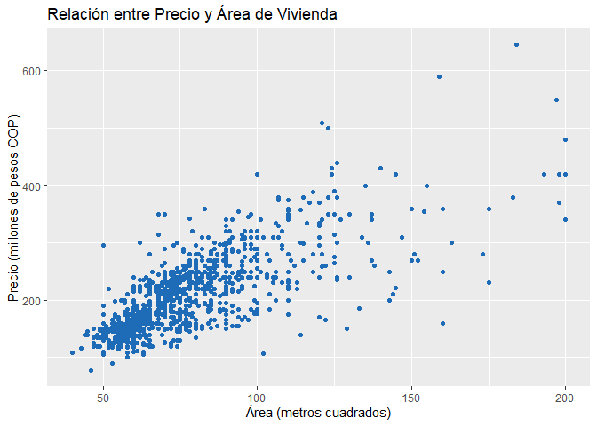

```r
# Gráfico dispersion para "areaconst" y "preciom"
ggplot(DatosFiltrado, aes(x = areaconst, y = preciom)) +
  geom_point(color = "#1E6BB8") +
  labs(title = "Relación entre Precio y Área de Vivienda", x = "Área (metros cuadrados)",
       y = "Precio (millones de pesos COP)")
```

### 2.3 Interpretación de resultados en relación al análisis entre la variable respuesta (precio) en función de la variable predictora (area construida):

El análisis bivariado entre el precio de la vivienda y el área construida revela una relación importante entre estas dos variables. El coeficiente de correlación de Pearson, que es de 0.7481389, indica una correlación positiva fuerte entre el precio de la vivienda y el área construida. Esta correlación sugiere que a medida que el área construida de las viviendas aumenta, el precio tiende a aumentar de manera significativa.

La interpretación de este coeficiente implica que existe una relación lineal positiva, lo que significa que a medida que una variable aumenta, la otra tiende a aumentar en una dirección similar. En este caso, a medida que el área construida de una vivienda aumenta, es probable que su precio aumente en una proporción similar.

## Punto No.03:

Estime el modelo de regresión lineal simple entre `precio=f(area)+ε`. Interprete los coeficientes del modelo `β0`, `β1` en caso de ser correcto:

```r
modelo_ln = lm(preciom ~ areaconst, data=DatosFiltrado)
summary(modelo_ln)
```

```
##
## Call:
## lm(formula = preciom ~ areaconst, data = DatosFiltrado)
##
## Residuals:
##      Min       1Q   Median       3Q      Max
## -225.404  -23.902   -4.754   25.763  209.021
##
## Coefficients:
##             Estimate Std. Error t value Pr(>|t|)
## (Intercept) 39.04679    4.09977   9.524   <2e-16 ***
## areaconst    2.16473    0.05204  41.595   <2e-16 ***
## ---
## Signif. codes:  0 '***' 0.001 '**' 0.01 '*' 0.05 '.' 0.1 ' ' 1
##
## Residual standard error: 43.34 on 1361 degrees of freedom
## Multiple R-squared:  0.5597, Adjusted R-squared:  0.5594
## F-statistic:  1730 on 1 and 1361 DF,  p-value: < 2.2e-16
```

El modelo de regresión lineal simple que relaciona el precio de la vivienda (preciom) con el área construida (areaconst) proporciona resultados significativos. La pendiente del modelo, representada por el coeficiente de areaconst (2.16473), indica que, en promedio, por cada metro cuadrado adicional de área construida, el precio de la vivienda aumenta en aproximadamente 2.16473 millones de pesos colombianos. Esto sugiere una relación positiva y significativa entre el área construida y el precio de la vivienda.

## Punto No.04:

Construir un intervalo de confianza (95%) para el coeficiente `β1`, interpretar y concluir si el coeficiente es igual a cero o no. Compare este resultado con una prueba de hipótesis t.

```r
confint(modelo_ln, level=0.95)
```

```
##                2.5 %    97.5 %
## (Intercept) 31.00423 47.089340
## areaconst    2.06264  2.266826
```

Los intervalos de confianza del 95% proporcionan una estimación de la variabilidad alrededor de los coeficientes del modelo. Para el coeficiente de “areaconst”, podemos decir con un 95% de confianza que el aumento esperado en el precio de la vivienda por metro cuadrado adicional se encuentra entre 2.06264 y 2.266826 millones de pesos colombianos. Esto proporciona una medida de la precisión de la estimación de la relación entre el área construida y el precio de la vivienda.

## Punto No.05:

Calcule e interprete el indicador de bondad R<sup>2</sup>:

```r
r2 = summary(modelo_ln)$r.squared
cat('El coeficiente de R2 es: ', r2)
```

```
## El coeficiente de R2 es:  0.5597117
```

Se evidencia un R<sup>2</sup> de 0.5597; lo que evidnecia que más del 50% de la variabilidad en el precio de la vivienda se puede explicar utilizando el área construida como predictor en el modelo. Esto indica que el modelo es bastante útil para predecir el precio de la vivienda en función del área construida, pero aún queda algo de variabilidad que no se explica. Pueden existir otros factores no considerados en el modelo que también influyen en el precio tales como la zona y el estrato de la vivienda.

## Punto No.06:

¿Cuál sería el precio promedio estimado para un apartamento de 110 metros cuadrados? Considera entonces con este resultado que un apartamento en la misma zona con 110 metros cuadrados en un precio de 200 millones sería una atractiva esta oferta? ¿Qué consideraciones adicionales se deben tener?.

```r
# Área del apartamento
area_apartamento <- 110

# Calcular el precio estimado
precio_estimado <- coef(modelo_ln)[1] + coef(modelo_ln)[2] * area_apartamento

# Calcular el intervalo de confianza para el precio estimado
intervalo_confianza <- predict(modelo_ln, newdata = data.frame(areaconst = area_apartamento), interval = "confidence", level = 0.95)

# Precio ofrecido por el apartamento en la misma zona
precio_ofrecido <- 200  # Precio ofrecido en millones de pesos colombianos

# Comparar el precio estimado con el precio ofrecido
if (precio_estimado < precio_ofrecido) {
  cat('La oferta es atractiva. El precio estimado es', round(precio_estimado, 2), 'millones de pesos colombianos, que es menor que el precio ofrecido de', precio_ofrecido, 'millones de pesos colombianos.\n')
} else if (precio_estimado > precio_ofrecido) {
  cat('La oferta no es atractiva. El precio estimado es', round(precio_estimado, 2), 'millones de pesos colombianos, que es mayor que el precio ofrecido de', precio_ofrecido, 'millones de pesos colombianos.\n')
} else {
  cat('La oferta tiene un precio justo. El precio estimado es igual al precio ofrecido de', precio_ofrecido, 'millones de pesos colombianos.\n')
}
```

```
## La oferta no es atractiva. El precio estimado es 277.17 millones de pesos colombianos, que es mayor que el precio ofrecido de 200 millones de pesos colombianos.
```

```r
# Imprimir el intervalo de confianza
cat('Intervalo de confianza para el precio estimado (95%): [', round(intervalo_confianza[1], 2), ' - ', round(intervalo_confianza[2], 2), '] millones de pesos colombianos.\n')
```

```
## Intervalo de confianza para el precio estimado (95%): [ 277.17  -  272.96 ] millones de pesos colombianos.
```

## Punto No.07:

Realice la validación de los supuestos del modelo por medio de gráficos apropiados, interpretarlos y sugerir posibles soluciones si se violan algunos de ellos. Utilice las pruebas de hipótesis para la validación de supuestos y compare los resultados con lo observado en los gráficos asociados.

## 7.1 Supuesto de Linealidad del modelo:

### 7.1.1 Graficación

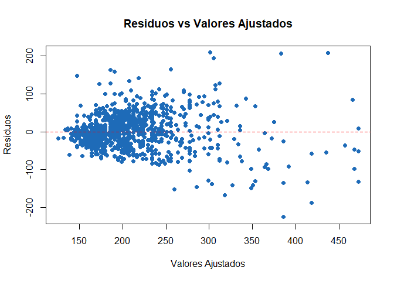

```r
residuos <- resid(modelo_ln)
valores_ajustados <- fitted(modelo_ln)

plot(valores_ajustados, residuos, xlab = "Valores Ajustados", ylab = "Residuos",
     main = "Residuos vs Valores Ajustados", pch = 19, col = "#1E6BB8")
abline(h = 0, col = "red", lty = 2)
```

### 7.1.2 Prueba de hipótesis

```r
# Prueba F para linealidad global
anova(modelo_ln, update(modelo_ln, . ~ 1))
```

```
## Analysis of Variance Table
##
## Model 1: preciom ~ areaconst
## Model 2: preciom ~ 1
##   Res.Df     RSS Df Sum of Sq      F    Pr(>F)
## 1   1361 2556313
## 2   1362 5805999 -1  -3249686 1730.2 < 2.2e-16 ***
## ---
## Signif. codes:  0 '***' 0.001 '**' 0.01 '*' 0.05 '.' 0.1 ' ' 1
```

## 7.2 Supuesto de Homocedasticidad del modelo:

### 7.2.1 Graficación

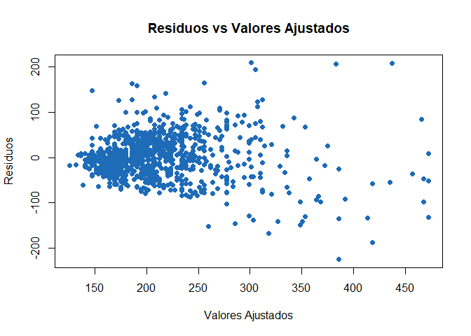

```r
# Gráfico de residuos frente a valores ajustados (predichos)
residuos <- resid(modelo_ln)
valores_ajustados <- fitted(modelo_ln)

plot(valores_ajustados, residuos, xlab = "Valores Ajustados", ylab = "Residuos",
     main = "Residuos vs Valores Ajustados", pch = 19, col = "#1E6BB8")
```

### 7.2.2 Prueba de hipótesis

```r
bptest(modelo_ln)
```

```
##
##  studentized Breusch-Pagan test
##
## data:  modelo_ln
## BP = 292.99, df = 1, p-value < 2.2e-16
```

### 7.2.3 Interpretación de resultados

Dado que el valor p (p-value) es extremadamente pequeño (menor que cualquier nivel de significancia común, como 0.05), hay evidencia contundente para rechazar la hipótesis nula de homocedasticidad. Esto significa que los residuos no tienen una varianza constante en todos los niveles de las variables independientes, lo que indica que no se cumple el supuesto de homocedasticidad.

## 7.3 Supuesto de Normalidad de los residuos del modelo:

### 7.3.1 Graficación

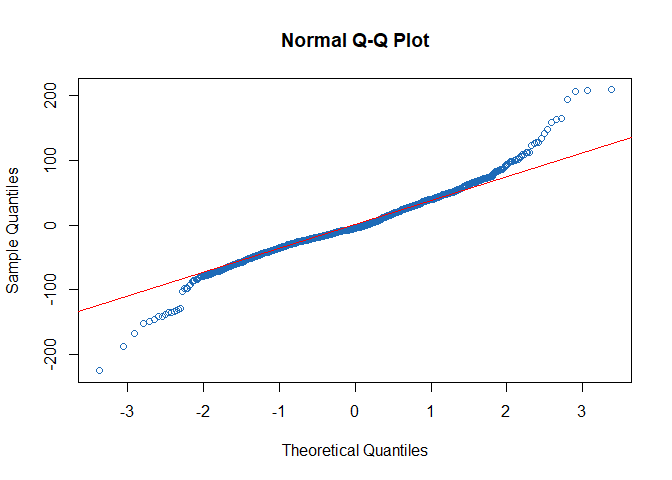

```r
# Gráfico Q-Q de los residuos
residuos <- resid(modelo_ln)
qqnorm(residuos, col = "#1E6BB8")
qqline(residuos, col = "red")
```

### 7.3.2 Prueba de hipótesis

```r
# Prueba de Shapiro-Wilk para normalidad
shapiro.test(residuos)
```

```
##
##  Shapiro-Wilk normality test
##
## data:  residuos
## W = 0.96486, p-value < 2.2e-16
```

### 7.3.3 Interpretación de resultados

Dado que el valor p (p-value) es extremadamente pequeño (menor que cualquier nivel de significancia común, como 0.05), hay evidencia contundente para rechazar la hipótesis nula de que los residuos siguen una distribución normal. Esto sugiere que los residuos no siguen una distribución normal.

## 7.4 Supuesto de Independencia de los residuos del modelo:

### 7.4.1 Graficación

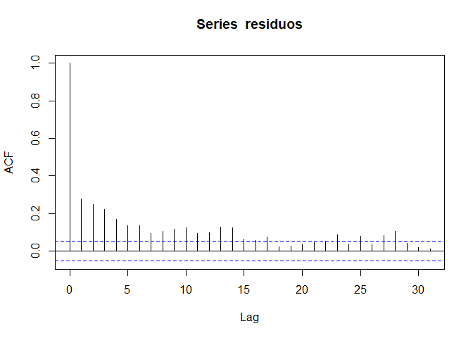

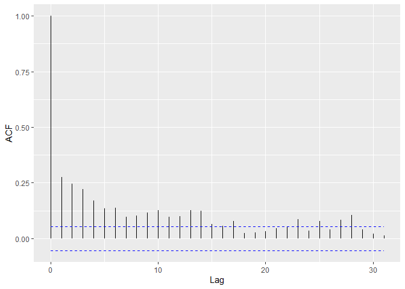

```r
# Gráfico de autocorrelación de los residuos
autoplot(acf(residuos))
```

### 7.4.2 Prueba de hipótesis

```r
# Prueba de Durbin-Watson para independencia
dwtest(modelo_ln)
```

```
##
##  Durbin-Watson test
##
## data:  modelo_ln
## DW = 1.443, p-value < 2.2e-16
## alternative hypothesis: true autocorrelation is greater than 0
```

### 7.4.3 Interpretación de resultados

Dado que el valor p (p-value) es extremadamente pequeño (menor que cualquier nivel de significancia común, como 0.05), hay evidencia contundente para rechazar la hipótesis nula de que no hay autocorrelación en los residuos. Esto sugiere que los residuos muestran evidencia de autocorrelación positiva, lo que indica que los valores sucesivos de los residuos están correlacionados.

## Punto No.08:

De ser necesario realice una transformación apropiada para mejorar el ajuste y supuestos del modelo.

### 8.1 Ajuste para Heterocedasticidad:

```r
# Ajuste del modelo de regresión lineal
modelo_ln <- lm(preciom ~ areaconst, data = DatosFiltrado)

# Calculo de estimaciones robustas de coeficientes
modelo_robusto <- coeftest(modelo_ln, vcov = vcovHC)
summary(modelo_robusto)
```

```
##     Estimate        Std. Error         t value          Pr(>|t|)
##  Min.   : 2.165   Min.   :0.09805   Min.   : 5.724   Min.   :0.000e+00
##  1st Qu.:11.385   1st Qu.:1.77886   1st Qu.: 9.813   1st Qu.:3.191e-09
##  Median :20.606   Median :3.45967   Median :13.901   Median :6.382e-09
##  Mean   :20.606   Mean   :3.45967   Mean   :13.901   Mean   :6.382e-09
##  3rd Qu.:29.826   3rd Qu.:5.14048   3rd Qu.:17.989   3rd Qu.:9.573e-09
##  Max.   :39.047   Max.   :6.82129   Max.   :22.078   Max.   :1.276e-08
```

### 8.2 Ajuste para Normalidad de Residuos:

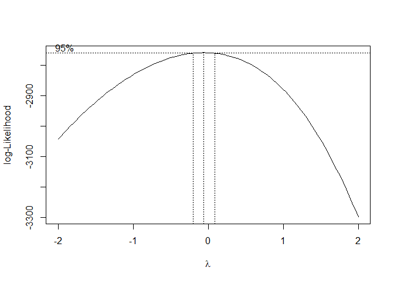

```r
# Ejemplo: Transformación de Box-Cox
lambda <- boxcox(modelo_ln)$x
```

```r
DatosFiltrado$preciom <- (DatosFiltrado$preciom^lambda - 1) / lambda
```

```r
# Ajuste del modelo de regresión lineal nuevamente
modelo_ln_transformado <- lm(preciom ~ areaconst, data = DatosFiltrado)
summary(modelo_ln_transformado)
```

```
##
## Call:
## lm(formula = preciom ~ areaconst, data = DatosFiltrado)
##
## Residuals:
##    Min     1Q Median     3Q    Max
##  -2883  -1155   -932   -786  40833
##
## Coefficients:
##             Estimate Std. Error t value Pr(>|t|)
## (Intercept)    58.14     361.62   0.161  0.87229
## areaconst      14.13       4.59   3.078  0.00213 **
## ---
## Signif. codes:  0 '***' 0.001 '**' 0.01 '*' 0.05 '.' 0.1 ' ' 1
##
## Residual standard error: 3823 on 1361 degrees of freedom
## Multiple R-squared:  0.006912,   Adjusted R-squared:  0.006183
## F-statistic: 9.473 on 1 and 1361 DF,  p-value: 0.002127
```

### 8.3 Ajuste para Autocorrelación:

```r
# Inclusión de una variable rezagada
DatosFiltrado$preciom_lagged <- c(NA, head(DatosFiltrado$preciom, -1))
modelo_con_lagged <- lm(preciom ~ areaconst + preciom_lagged, data = DatosFiltrado)
summary(modelo_con_lagged)
```

```
##
## Call:
## lm(formula = preciom ~ areaconst + preciom_lagged, data = DatosFiltrado)
##
## Residuals:
##    Min     1Q Median     3Q    Max
## -29124   -422   -233   -115  33902
##
## Coefficients:
##                 Estimate Std. Error t value Pr(>|t|)
## (Intercept)    -583.2050   267.1457  -2.183  0.02920 *
## areaconst        12.5728     3.3822   3.717  0.00021 ***
## preciom_lagged    0.6748     0.0199  33.917  < 2e-16 ***
## ---
## Signif. codes:  0 '***' 0.001 '**' 0.01 '*' 0.05 '.' 0.1 ' ' 1
##
## Residual standard error: 2815 on 1359 degrees of freedom
##   (1 observation deleted due to missingness)
## Multiple R-squared:  0.4622, Adjusted R-squared:  0.4614
## F-statistic: 583.9 on 2 and 1359 DF,  p-value: < 2.2e-16
```

### 8.4 Ajuste para el supuesto de linealidad:

```r
# Gestión de un modelo polinómico
modelo_no_lineal <- lm(preciom ~ poly(areaconst, 2), data = DatosFiltrado)
summary(modelo_no_lineal)
```

```
##
## Call:
## lm(formula = preciom ~ poly(areaconst, 2), data = DatosFiltrado)
##
## Residuals:
##    Min     1Q Median     3Q    Max
##  -1916  -1293   -886   -605  40659
##
## Coefficients:
##                     Estimate Std. Error t value Pr(>|t|)
## (Intercept)           1124.5      103.4  10.876   <2e-16 ***
## poly(areaconst, 2)1  11765.6     3817.2   3.082   0.0021 **
## poly(areaconst, 2)2  -8452.2     3817.2  -2.214   0.0270 *
## ---
## Signif. codes:  0 '***' 0.001 '**' 0.01 '*' 0.05 '.' 0.1 ' ' 1
##
## Residual standard error: 3817 on 1360 degrees of freedom
## Multiple R-squared:  0.01048,    Adjusted R-squared:  0.009024
## F-statistic: 7.202 on 2 and 1360 DF,  p-value: 0.0007741
```

## Punto No.09:

De ser necesario compare el ajuste y supuestos del modelo inicial y el transformado.

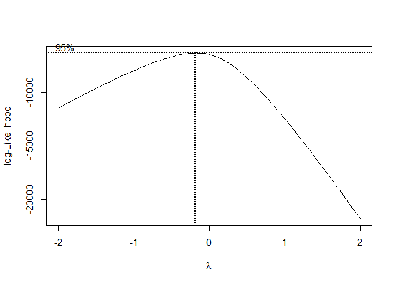

```r
# Ajustar el modelo de regresión lineal original
modelo_ln <- lm(preciom ~ areaconst, data = DatosFiltrado)

# Ajustar el modelo de regresión lineal con la transformación Box-Cox
lambda <- boxcox(modelo_ln)$x
```

```r
DatosFiltrado$preciom_transformado <- (DatosFiltrado$preciom^lambda - 1) / lambda
```

```r
modelo_ln_transformado <- lm(preciom_transformado ~ areaconst, data = DatosFiltrado)

# Realizar la prueba Breusch-Pagan para homocedasticidad en el modelo original
bptest(modelo_ln)
```

```
##
##  studentized Breusch-Pagan test
##
## data:  modelo_ln
## BP = 6.4029, df = 1, p-value = 0.01139
```

```r
# Realizar la prueba Breusch-Pagan para homocedasticidad en el modelo transformado
bptest(modelo_ln_transformado)
```

```
##
##  studentized Breusch-Pagan test
##
## data:  modelo_ln_transformado
## BP = 0.17745, df = 1, p-value = 0.6736
```

```r
# Realizar la prueba de Shapiro-Wilk para normalidad de residuos en el modelo original
shapiro.test(resid(modelo_ln))
```

```
##
##  Shapiro-Wilk normality test
##
## data:  resid(modelo_ln)
## W = 0.37006, p-value < 2.2e-16
```

```r
# Realizar la prueba de Shapiro-Wilk para normalidad de residuos en el modelo transformado
shapiro.test(resid(modelo_ln_transformado))
```

```
##
##  Shapiro-Wilk normality test
##
## data:  resid(modelo_ln_transformado)
## W = 0.095489, p-value < 2.2e-16
```

```r
# Realizar la prueba de Durbin-Watson para independencia en el modelo original
dwtest(modelo_ln)
```

```
##
##  Durbin-Watson test
##
## data:  modelo_ln
## DW = 0.64397, p-value < 2.2e-16
## alternative hypothesis: true autocorrelation is greater than 0
```

```r
# Realizar la prueba de Durbin-Watson para independencia en el modelo transformado
dwtest(modelo_ln_transformado)
```

```
##
##  Durbin-Watson test
##
## data:  modelo_ln_transformado
## DW = 1.42, p-value < 2.2e-16
## alternative hypothesis: true autocorrelation is greater than 0
```

La transformación Box-Cox permitió mejorar la homocedasticidad y la autocorrelación de los residuos, pero no ha permitido mejorar la normalidad de los residuos. Por lo anterior, se sugiere considerar otras transformaciones o métodos para abordar la falta de normalidad en los residuos.

## Punto No.10:

Estime otros modelos y compare los resultados obtenidos. En el mejor de los modelos, ¿se cumplen los supuestos sobre los errores?

```r
# Adicion de la zona de la vivienda al Modelo
modelo_ln_zona = lm(preciom ~ areaconst + zona, data=DatosFiltrado)
summary(modelo_ln_zona)
```

```
##
## Call:
## lm(formula = preciom ~ areaconst + zona, data = DatosFiltrado)
##
## Residuals:
##    Min     1Q Median     3Q    Max
##  -3847  -1184   -943   -445  39102
##
## Coefficients:
##                   Estimate Std. Error t value Pr(>|t|)
## (Intercept)        588.520   1520.611   0.387  0.69880
## areaconst           14.767      4.603   3.208  0.00137 **
## zonaZona Norte   -1220.990   1464.689  -0.834  0.40464
## zonaZona Oeste    1147.577   1538.647   0.746  0.45590
## zonaZona Oriente   244.204   3050.885   0.080  0.93621
## zonaZona Sur      -525.243   1450.265  -0.362  0.71728
## ---
## Signif. codes:  0 '***' 0.001 '**' 0.01 '*' 0.05 '.' 0.1 ' ' 1
##
## Residual standard error: 3803 on 1357 degrees of freedom
## Multiple R-squared:  0.01985,    Adjusted R-squared:  0.01624
## F-statistic: 5.498 on 5 and 1357 DF,  p-value: 5.112e-05
```

```r
# Extraer los valores necesarios del resumen del modelo original
coeficientes_ln <- coef(modelo_ln)
r_cuadrado_ln <- summary(modelo_ln)$r.squared
residual_std_error_ln <- summary(modelo_ln)$sigma

# Extraer los valores necesarios del resumen del modelo con zona
coeficientes_ln_zona <- coef(modelo_ln_zona)
r_cuadrado_ln_zona <- summary(modelo_ln_zona)$r.squared
residual_std_error_ln_zona <- summary(modelo_ln_zona)$sigma

# Crear una tabla manualmente
tabla_comparativa <- data.frame(
  Modelo = c("Modelo Original", "Modelo con Zona"),
  Coeficiente_Intercepto = c(coeficientes_ln[1], coeficientes_ln_zona[1]),
  Coeficiente_Areaconst = c(coeficientes_ln[2], coeficientes_ln_zona[2]),
  R_Cuadrado = c(r_cuadrado_ln, r_cuadrado_ln_zona),
  Residual_Std_Error = c(residual_std_error_ln, residual_std_error_ln_zona)
)

# Imprimir la tabla en formato Markdown
knitr::kable(tabla_comparativa, format = "markdown")
```

| Modelo | Coeficiente_Intercepto | Coeficiente_Areaconst | R_Cuadrado | Residual_Std_Error |
| --- | --- | --- | --- | --- |
| Modelo Original | 58.14059 | 14.12861 | 0.0069124 | 3822.661 |
| Modelo con Zona | 588.52020 | 14.76713 | 0.0198550 | 3803.263 |

## Punto No.11: Informe Final

### 1. Resumen de los Datos:

Hemos realizado un análisis exploratorio de los datos relacionados con la oferta de apartamentos. El dataset contiene información sobre la zona, el estrato, el precio, el área construida y el tipo de vivienda. El dataset se filtró para incluir solo apartamentos.

### 2. Estadísticas Descriptivas:

- El precio promedio de las viviendas es de 202.44 millones de pesos COP.
- La mediana del precio es de 185 millones de pesos COP.
- La moda es de 150 millones de pesos COP.
- El precio mínimo es de 78 millones de pesos COP, mientras que el precio máximo es de 645 millones de pesos COP.
- El área construida promedio es de 75.48 metros cuadrados, con una mediana de 70 metros cuadrados.

### 3. Análisis de la relación entre precio y área construida:

Hemos calculado el coeficiente de correlación de Pearson, que es de 0.7481389. Esto indica una correlación positiva fuerte entre el precio de la vivienda y el área construida. A medida que el área construida aumenta, el precio tiende a aumentar.

### 4. Modelo de Regresión Lineal Simple:

Hemos estimado un modelo de regresión lineal simple para predecir el precio de la vivienda en función del área construida. El modelo es: `Precio = β0 + β1 * Área + ε`

- β0 (intercepto) = 39.04679
- β1 (coeficiente de área) = 2.16473

### 5. Intervalo de Confianza para β1:

Hemos calculado un intervalo de confianza del 95% para el coeficiente β1, que va de 2.06264 a 2.266826. Esto indica que el aumento esperado en el precio por cada metro cuadrado adicional se encuentra en este rango.

### 6. Coeficiente de Determinación (R^2):

El R^2 del modelo es 0.5597, lo que significa que más del 55% de la variabilidad en el precio de la vivienda se puede explicar utilizando el área construida como predictor en el modelo.

Hemos realizado pruebas y gráficos para validar los supuestos del modelo. Se encontraron violaciones en los siguientes supuestos:

### 9. Soluciones Propuestas:

- Para el no cumplimiento del supuesto de linealidad, podría ser necesario considerar una transformación de variables.
- Para el no cumplimiento de homocedasticidad, podríamos utilizar estimaciones robustas de coeficientes o considerar otras variables.
- Para el no cumplimiento de normalidad de residuos, podríamos explorar diferentes transformaciones de variables.
- Para la autocorrelación de residuos, podríamos considerar otras variables predictoras o utilizar técnicas de series temporales.

En conclusion, se puede inferir que el modelo actual tiene limitaciones y no satisface completamente los supuestos de la regresión lineal simple. Se requiere un análisis más detallado y posiblemente la inclusión de otras variables para mejorar el ajuste del modelo y satisfacer los supuestos. Además, se deben considerar otros factores importantes en la valoración de bienes raíces, como la ubicación, el estrato y las comodidades adicionales.